**Spatial Research**

# 1 Overview

## 1.1 Methodology

- Data Prepare
- OLS Regression
  - Hypothesis
  - Distribution Correction
  - OLS with std error
  - VIF (remove multicollinearity)
  - Regression
  - Residual Analysis
- Moran's I Test
- GWR

According to [EDA analysis](https://zeqiang.fun/CASA0012-Dissertation/jupyterlab/EDA.html), It can be found that most of tech firms are clustered in the England. In the next step, this research will focus more on the England country. `ctry` can be a filter to get the `country == 'England'` tech firms information. HHI can be calculate in the below function：

$$ Herfindahl-Hirschman \ Index_{i,t} = \sum_1^k (\frac{Tech\ Firms_{i,t,k}}{Total\ Tech\ Firms_{i,t}})^2 $$

Where the HH index will be calculated from industry `1` to `k` in location `i` and year `t`. This formula means, in year `t` and location `i`, the number of tech firms which belong to industry `k` divide that of the total firms. This index can measure how diverse the tech cluster are.

Hypothesis is given below:

$\ log_e\ {Dynamics\ Variable_{i,t}}\ =\ a_1 + b_1 \times firms_{i,t} + b_2 \times HHI_{i,t} + b_3 \times location_i + b_4 \times year_t$ (1)

$\ log_e\ {(Firm\ Performance_{i,t}+1)}\ =\ c_1 + d_1 \times firms_{i,t} + d_2 \times HHI_{i,t} + d_3 \times dynamics_{i,t} + d_4 \times location_i + d_5 \times year_t$ (2)

- $t$ means year -- `birth_year`
- $i$ means location -- `ttwa` (travel to work area)
- $Dynamics\ Variable_{i,t}$ in (1) means `Entry_Rate` in $t$ and $i$
- $dynamics_{i,t}$ in (2) means `Entry_Rate` in a specific $t$ and $i$
- $firms_{i,t}$ means `Count_of_tech_firms` in a specific $t$ and $i$
- $HHI_{i,t}$ means `Herfindahl-Hirschman Index` in a specific $t$ and $i$

## 1.2 Results

Industry Mix V.S. Dynamics:

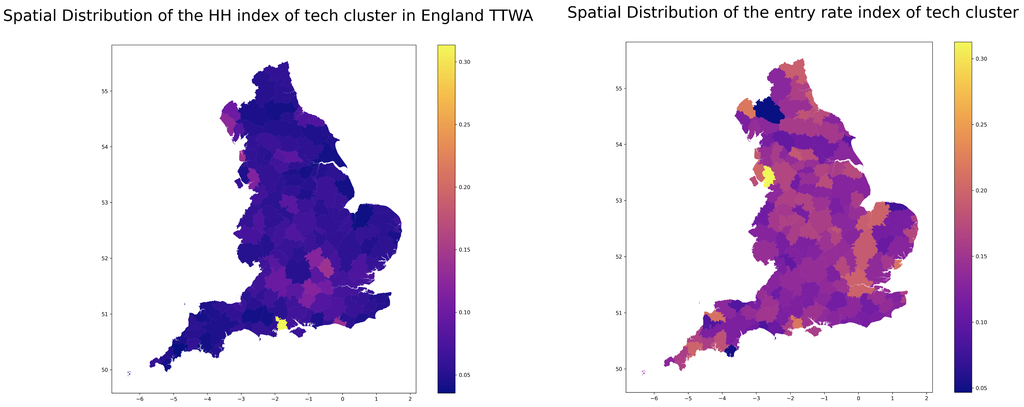

- Regression OLS in (1)
- the residual analysis in (1)
- Regression OLS in (2)
- the residual analysis in (2)

# 2 Reproducible Analysis: HH index

HH index can be treated to measure the tech industry diversity. For calculate industry mix level, `primary_sic_code` will be utilised to do a `group by` operation

According to [EDA analysis](https://zeqiang.fun/CASA0012-Dissertation/jupyterlab/EDA.html), It can be found that most of tech firms are clustered in the England. In the next step, this research will focus more on the England country. `ctry` can be a filter to get the `country == 'England'` tech firms information

```python
#read data
import sys
import pandas as pd
PATH = sys.path[0]
df = pd.read_csv(PATH + "/Dataset/fame_OC_tech_firm.csv",low_memory = False)
dfp = df.drop({"Unnamed: 0","Unnamed: 0.1","Unnamed: 0.1.1","is_tech"},axis=1)

# data select
# dfp means df is processed
dfp = dfp[["registered_number","diss_year","birth_year","primary_uk_sic_2007","ttwa","ctry"]]

# dna means drop na value
dfp_dna = dfp.dropna(subset=["birth_year","ttwa"]).reset_index(drop=True)

# introduce the ttwa to filter england firms
# dfp_dna = dfp_dna[dfp_dna.ctry=="E92000001"]
dfp_dna = dfp_dna[dfp_dna.birth_year >= 1998]

#export to the excel to do operation
df_excel = dfp_dna.copy()
# df_excel.to_excel(PATH + "/tech_cluster_ttwa_in_England.xlsx")
```

```python
# process the .csv file
df_excel = pd.read_excel(PATH + "/MySQL/tech_cluster_ttwa_in_England.xlsx")
df_excel = df_excel.fillna(0)
# df_excel.to_csv(PATH + "/MySQL/tech_cluster_ttwa_in_England.csv")
```

```python
df_excel.head()
```

[output not shown]

After pivot operation in the Excel, the dataset is also imported into MySQL to calculate the HH index.

The method/code is presented below:

```
CREATE TABLE tech_cluster_hh
SELECT t2.ttwa, t2.birth_year, sum(t2.sub_hh) as hh
FROM (SELECT t0.ttwa,
            t0.birth_year,
            t0.primary_uk_sic_2007,
            power(count(t0.registered_number)/t1.year_total,2) as sub_hh
            FROM `casa-dissertation`.tech_cluster_ttwa_in_England_year_98218_sic as t0,
                (SELECT ttwa,
                        birth_year,
                        count(registered_number) as year_total
                        FROM `casa-dissertation`.tech_cluster_ttwa_in_England_year_98218_sic
                        GROUP BY ttwa, birth_year) as t1
            WHERE t0.ttwa = t1.ttwa and t0.birth_year = t1.birth_year
            GROUP BY t0.ttwa, t0.birth_year, t0.primary_uk_sic_2007 ) as t2
GROUP BY t2.ttwa, t2.birth_year
```

Then import this processed `.csv` to get HH index from two scale (location&year, location)

**【HH index in TTWA and Year】**

method from `MySQL/hh_index.sql`

input from the `tech_cluster_ttwa_in_England_year_98218_sic` table

output from `tech_cluster_hhtech_cluster_hh` table

```python
# means HH index in year t and location
import pandas as pd
import sys
PATH = sys.path[0]
df_hh_i_t = pd.read_csv(PATH + "/MySQL/tech_cluster_hh.csv",",")
df_hh_i_t.head()
```

|  | ttwa | birth_year | hh |
| --- | --- | --- | --- |
| 0 | E30000237 | 1998 | 0.147377 |
| 1 | E30000212 | 1998 | 0.110137 |
| 2 | E30000292 | 1998 | 0.218935 |
| 3 | E30000234 | 1998 | 0.084710 |
| 4 | E30000245 | 1998 | 0.155709 |

**【HH index in TTWA】**

method from `MySQL/hh_index_drop_year.sql`

input from the `tech_cluster_ttwa_in_England_year_98218_sic` table

output from the `tech_cluster_hh_ttwa` table

```
CREATE TABLE tech_cluster_hh_ttwa
SELECT t2.ttwa, sum(t2.sub_hh_2) as hh
FROM ( SELECT   t0.ttwa,
                t0.primary_uk_sic_2007,
                power(count(t0.registered_number)/t1.ttwa_total,2) as sub_hh_2
                FROM `casa-dissertation`.tech_cluster_ttwa_in_England_year_98218_sic as t0,
                    (SELECT ttwa,
                            count(registered_number) as ttwa_total
                            FROM `casa-dissertation`.tech_cluster_ttwa_in_England_year_98218_sic
                            WHERE diss_year = 0  -- diss year's firms should be excluded
                            GROUP BY ttwa) as t1
                WHERE t0.ttwa = t1.ttwa and t0.diss_year = 0 -- diss year's firms should be excluded
                GROUP BY t0.ttwa, t0.primary_uk_sic_2007 ) as t2
GROUP BY t2.ttwa
```

```python
# means HH index in year t and location i
df_hh_i = pd.read_csv(PATH + "/MySQL/tech_cluster_hh_ttwa_only.csv",",")
df_hh_i.head()
```

|  | ttwa | hh |
| --- | --- | --- |
| 0 | E30000237 | 0.141279 |
| 1 | E30000212 | 0.081876 |
| 2 | E30000292 | 0.058302 |
| 3 | E30000234 | 0.070716 |
| 4 | E30000245 | 0.053532 |

# Map Visualisation

import the geo dataset for ttwa in the England

```python
# spatial map prepare
# read spatial data
import geopandas as gpd
g_ttwa = gpd.read_file(PATH + "/Dataset/Spatial/Travel_to_Work_Areas__December_2011__Generalised_Clipped_Boundaries_in_United_Kingdom.geojson")
```

According to [CSDN](https://blog.csdn.net/weixin_44122191/article/details/109008193), I ustilise the below method to filter string

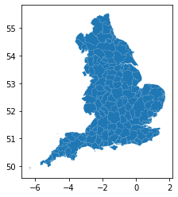

```python
# print(g_ttwa.TTWA11CD.value_counts())
# input
df_tmp = g_ttwa.copy()
df_tmp.col_tmp = g_ttwa.TTWA11CD
letter_str_1 = "E"
# letter_str_2 = "K"

mask = [True if i[0]==letter_str_1 else False for i in df_tmp.col_tmp]

# output
g_ttwa_England = df_tmp[mask]
# print(g_ttwa_England.TTWA11CD.value_counts())
g_ttwa_England.plot()
```

```python
# inspect the data
g_ttwa_England.head(1)
```

|  | OBJECTID | TTWA11CD | TTWA11NM | Shape__Area | Shape__Length | geometry |
| --- | --- | --- | --- | --- | --- | --- |
| 0 | 1 | E30000004 | Barnsley | 3.424992e+08 | 129308.31911 | POLYGON ((-1.44681 53.61282, -1.44475 53.61061... |

## Industry Mix: HHI

```python
# inspect the data
df_hh_i.head(1)
```

[output not shown]

```python
# merge with `df_hh_i`

df_ttwa_hh_mg = pd.merge(g_ttwa,df_hh_i, left_on='TTWA11CD',right_on="ttwa",how = "inner").reset_index(drop=True)
df_ttwa_hh_mg.head()
```

|  | OBJECTID | TTWA11CD | TTWA11NM | Shape__Area | Shape__Length | geometry | ttwa | hh |
| --- | --- | --- | --- | --- | --- | --- | --- | --- |
| 0 | 1 | E30000004 | Barnsley | 3.424992e+08 | 129308.319110 | POLYGON ((-1.44681 53.61282, -1.44475 53.61061... | E30000004 | 0.045157 |
| 1 | 2 | E30000018 | Bradford | 3.438902e+08 | 119605.015955 | POLYGON ((-1.94399 53.95619, -1.94161 53.95252... | E30000018 | 0.081738 |
| 2 | 3 | E30000029 | Halifax | 3.639425e+08 | 105182.259501 | POLYGON ((-2.03257 53.81023, -2.03138 53.80902... | E30000029 | 0.067777 |
| 3 | 4 | E30000039 | Skipton | 1.178893e+09 | 197077.350855 | POLYGON ((-2.30733 54.25008, -2.30511 54.24934... | E30000039 | 0.062993 |
| 4 | 5 | E30000046 | Dorchester and Weymouth | 7.200201e+08 | 226091.682220 | MULTIPOLYGON (((-2.22501 50.61646, -2.22520 50... | E30000046 | 0.059792 |

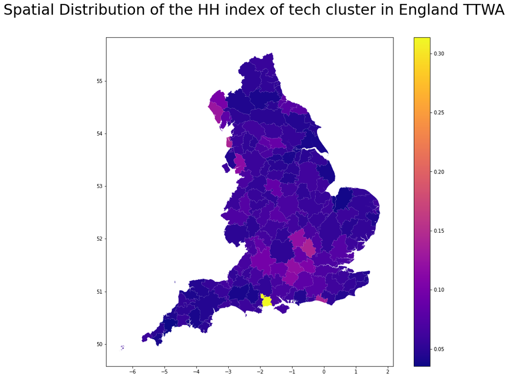

```python
title_text = "Spatial Distribution of the HH index of tech cluster in England TTWA"

df_left = g_ttwa
left_key = 'TTWA11CD'

df_right = df_hh_i
right_key = "ttwa"

map_attribute = "hh"


# merge
df_mg = pd.merge(df_left,df_right, left_on = left_key,right_on=right_key,how = "inner").reset_index(drop=True)
# map
import pysal as ps
import numpy as np
import pandas as pd
import seaborn as sns
import geopandas as gpd
import matplotlib.pyplot as plt

tfont = {'fontname':'DejaVu Sans', 'horizontalalignment':'left'}
f1 = plt.figure()
f1.set_size_inches(15,12)

ax1 = f1.add_subplot()
df_mg.plot(column = map_attribute, legend=True, cmap='plasma',linestyle='solid', ax=ax1)
# df_ttwa_hh_mg.plot(column='count', legend=True, cmap='plasma',figsize=(180,60),ax=ax1)

f1.subplots_adjust(top=0.9)
f1.suptitle(title_text, x=0.01, size=30, **tfont)
f1.savefig(PATH + "/Img/" + title_text + ".png", dpi=300)
```

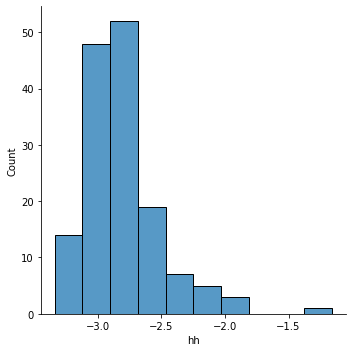

```python
import seaborn as sns
import numpy as np
df = df_ttwa_hh_mg.copy()
df.hh = np.log(df.hh)
attributes = "hh"
sns.displot(df, x=attributes,bins=10)
```

## Dynamics: Entry Rate

```python
# read data

# means Entry Rate in location i
df_EnR_i = pd.read_excel(PATH + "/Excel/tech_cluster_ttwa_in_England_EnR.xlsx", sheet_name = "ttwa_EnR")
df_EnR_i.head()
```

|  | ttwa | 2018 | total | Entry_Rate |
| --- | --- | --- | --- | --- |
| 0 | E30000004 | 93 | 749 | 0.124166 |
| 1 | E30000018 | 334 | 1771 | 0.188594 |
| 2 | E30000029 | 132 | 945 | 0.139683 |
| 3 | E30000039 | 23 | 225 | 0.102222 |
| 4 | E30000046 | 66 | 623 | 0.105939 |

The template method is writen below

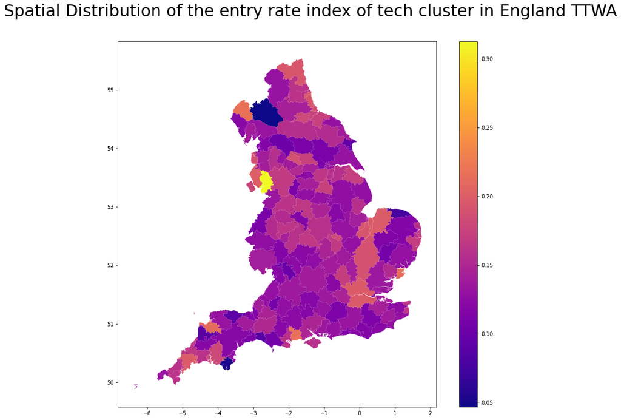

```python
title_text = "Spatial Distribution of the entry rate index of tech cluster in England TTWA"

df_left = g_ttwa
left_key = 'TTWA11CD'

df_right = df_EnR_i
right_key = "ttwa"

map_attribute = "Entry_Rate"


# merge
df_mg = pd.merge(df_left,df_right, left_on = left_key,right_on=right_key,how = "inner").reset_index(drop=True)

# map
import pysal as ps
import numpy as np
import pandas as pd
import seaborn as sns
import geopandas as gpd
import matplotlib.pyplot as plt

tfont = {'fontname':'DejaVu Sans', 'horizontalalignment':'left'}
f1 = plt.figure()
f1.set_size_inches(15,12)

ax1 = f1.add_subplot()
df_mg.plot(column = map_attribute, legend=True, cmap='plasma', linestyle='solid', ax=ax1)
# df_ttwa_hh_mg.plot(column='count', legend=True, cmap='plasma',figsize=(180,60),ax=ax1)

f1.subplots_adjust(top=0.9)
f1.suptitle(title_text, x=0.01, size=30, **tfont)
# f1.savefig(PATH + "/Img/" + title_text + ".png", dpi=300)
```

## Industry Mix V.S. Dynamics

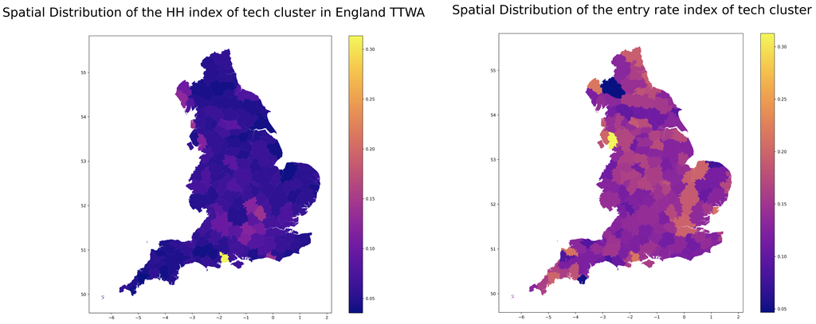

# Regression

1. Hypothesis
2. Data Prepare
3. Distribution EDA
4. OLS with std error
5. VIF
6. Regression
7. Residual

## Data Preparation

```python
# the last dataset
import pandas as pd
import sys
PATH = sys.path[0]

df = pd.read_csv(PATH + "/Dataset/fame_OC_tech_firm.csv",low_memory=False)
df = df.drop({"Unnamed: 0","Unnamed: 0.1","Unnamed: 0.1.1","is_tech"},axis = 1)

# preprocess the data
# drop the null value record in birth year and ttwa(travel to work area) columns
df = df.dropna(subset = {"birth_year","ttwa"})

# England's filter can be processed in the final stage with merge function
# filter by `birth_year`
# df_10_tc_20 means "top 10 tech ttwa clusters in 20 years dataframe"
df = df[df["birth_year"]>=1998].reset_index(drop=True)

# select data in below columns
df = df[["registered_number",\
        "ttwa",\
        "birth_year",\
        "diss_year",\
        "latest_accounts_assets"]]

df.head()
df_EnR_i_t = df.copy()
df_EnR_i_t.head()
```

|  | registered_number | ttwa | birth_year | diss_year | latest_accounts_assets |
| --- | --- | --- | --- | --- | --- |
| 0 | SC586896 | S22000047 | 2018.0 | NaN | NaN |
| 1 | SC288343 | S22000047 | 2005.0 | NaN | 1751549.0 |
| 2 | SC500426 | S22000047 | 2015.0 | NaN | NaN |
| 3 | SC216869 | S22000047 | 2001.0 | NaN | 169943.0 |
| 4 | SC366379 | S22000047 | 2009.0 | NaN | NaN |

```python
df1 = df_EnR_i_t.copy()
```

```python
# MITO CODE START (DO NOT EDIT)

from mitosheet import * # Import necessary functions from Mito
register_analysis('UUID-e910eec5-8991-430a-8ba4-f9ddcc5283bc') # Let Mito know which analysis is being run

# Step 1

df2 = pd.DataFrame(data={})

# MITO CODE END (DO NOT EDIT)
```

```python
# MITO CODE START (DO NOT EDIT)

from mitosheet import * # Import necessary functions from Mito
register_analysis('UUID-e910eec5-8991-430a-8ba4-f9ddcc5283bc') # Let Mito know which analysis is being run

# Step 1

df2 = pd.DataFrame(data={})

# MITO CODE END (DO NOT EDIT)
```

```python
# MITO CODE START (DO NOT EDIT)

from mitosheet import * # Import necessary functions from Mito
register_analysis('UUID-e910eec5-8991-430a-8ba4-f9ddcc5283bc') # Let Mito know which analysis is being run

# Step 1

df2 = pd.DataFrame(data={})

# MITO CODE END (DO NOT EDIT)
```

```python
# MITO CODE START (DO NOT EDIT)

from mitosheet import * # Import necessary functions from Mito
register_analysis('UUID-e910eec5-8991-430a-8ba4-f9ddcc5283bc') # Let Mito know which analysis is being run

# Step 1

# Pivot the data
pivot_table = df1.pivot_table(
    index=['ttwa', 'birth_year'],
    values=['registered_number'],
    aggfunc={'registered_number': 'count'}
)

# Reset the column name and the indexes
df2 = pivot_table.rename_axis(None, axis=1).reset_index()

# MITO CODE END (DO NOT EDIT)
```

```python
# MITO CODE START (DO NOT EDIT)

from mitosheet import * # Import necessary functions from Mito
register_analysis('UUID-e910eec5-8991-430a-8ba4-f9ddcc5283bc') # Let Mito know which analysis is being run

# Step 1

# Pivot the data
pivot_table = df1.pivot_table(
    index=['ttwa', 'birth_year'],
    values=['registered_number'],
    aggfunc={'registered_number': 'count'}
)

# Reset the column name and the indexes
df2 = pivot_table.rename_axis(None, axis=1).reset_index()

# MITO CODE END (DO NOT EDIT)
```

```python
# MITO CODE START (DO NOT EDIT)

from mitosheet import * # Import necessary functions from Mito
register_analysis('UUID-e910eec5-8991-430a-8ba4-f9ddcc5283bc') # Let Mito know which analysis is being run

# Step 1

# Pivot the data
pivot_table = df1.pivot_table(
    index=['ttwa', 'birth_year'],
    values=['registered_number', 'latest_accounts_assets'],
    aggfunc={'registered_number': 'count', 'latest_accounts_assets': 'count'}
)

# Reset the column name and the indexes
df2 = pivot_table.rename_axis(None, axis=1).reset_index()

# MITO CODE END (DO NOT EDIT)
```

```python
# MITO CODE START (DO NOT EDIT)

from mitosheet import * # Import necessary functions from Mito
register_analysis('UUID-e910eec5-8991-430a-8ba4-f9ddcc5283bc') # Let Mito know which analysis is being run

# Step 1

# Pivot the data
pivot_table = df1.pivot_table(
    index=['ttwa', 'birth_year'],
    values=['registered_number', 'latest_accounts_assets'],
    aggfunc={'registered_number': 'count', 'latest_accounts_assets': 'mean'}
)

# Reset the column name and the indexes
df2 = pivot_table.rename_axis(None, axis=1).reset_index()

# MITO CODE END (DO NOT EDIT)
```

```python
df_EnR_i_t_pivot = df2.copy()
df_EnR_i_t_pivot = df_EnR_i_t_pivot.rename({"latest_accounts_assets":"average_assets","registered_number":"firms"},axis=1)
df_EnR_i_t_pivot.head()
```

|  | ttwa | birth_year | average_assets | firms |
| --- | --- | --- | --- | --- |
| 0 | E30000004 | 1998.0 | 19405.250000 | 10 |
| 1 | E30000004 | 1999.0 | 759500.500000 | 6 |
| 2 | E30000004 | 2000.0 | 286162.333333 | 8 |
| 3 | E30000004 | 2001.0 | 129527.428571 | 8 |
| 4 | E30000004 | 2002.0 | 56740.400000 | 11 |

```python
# group by ttwa come up with entry rate
df = df_EnR_i_t_pivot.copy()

df_tmp = df.groupby('ttwa').agg({"firms":sum}).rename({"firms":"total_firms"},axis=1).reset_index()

dfm = pd.merge(df, df_tmp, left_on = 'ttwa', right_on = 'ttwa', how='inner') # vlookup like function

dfm["entry_rate"] = dfm.firms/dfm.total_firms

dfm.head()

df_EnR_i_t = dfm.copy()
```

```python
df_EnR_i_t = df_EnR_i_t.fillna(0)
df_EnR_i_t.birth_year = df_EnR_i_t.birth_year.astype(int)
df_EnR_i_t.head()
```

|  | ttwa | birth_year | average_assets | firms | total_firms | entry_rate |
| --- | --- | --- | --- | --- | --- | --- |
| 0 | E30000004 | 1998 | 19405.250000 | 10 | 749 | 0.013351 |
| 1 | E30000004 | 1999 | 759500.500000 | 6 | 749 | 0.008011 |
| 2 | E30000004 | 2000 | 286162.333333 | 8 | 749 | 0.010681 |
| 3 | E30000004 | 2001 | 129527.428571 | 8 | 749 | 0.010681 |
| 4 | E30000004 | 2002 | 56740.400000 | 11 | 749 | 0.014686 |

```python
df_left = df_EnR_i_t
left_key = ["ttwa","birth_year"]
print("Entry Rate Dataset is" + str(df_EnR_i_t.shape) + " because it includes other countries like Scotland, Wales")

df_right = df_hh_i_t
right_key = ["ttwa","birth_year"]
print("HHI Dataset is" + str(df_hh_i_t.shape))

# merge
df_mg = pd.merge(df_left,df_right, left_on=left_key, right_on=right_key,how = "inner").reset_index(drop=True)

df_hh_EnR = df_mg.copy()
print("HHI&EnR Dataset is" + str(df_hh_EnR.shape))

df_hh_EnR.head()
```

```
Entry Rate Dataset is(4487, 6) because it includes other countries like Scotland, Wales
HHI Dataset is(3089, 3)
HHI&EnR Dataset is(3089, 7)
```

|  | ttwa | birth_year | average_assets | firms | total_firms | entry_rate | hh |
| --- | --- | --- | --- | --- | --- | --- | --- |
| 0 | E30000004 | 1998 | 19405.250000 | 10 | 749 | 0.013351 | 0.120000 |
| 1 | E30000004 | 1999 | 759500.500000 | 6 | 749 | 0.008011 | 0.333333 |
| 2 | E30000004 | 2000 | 286162.333333 | 8 | 749 | 0.010681 | 0.156250 |
| 3 | E30000004 | 2001 | 129527.428571 | 8 | 749 | 0.010681 | 0.125000 |
| 4 | E30000004 | 2002 | 56740.400000 | 11 | 749 | 0.014686 | 0.090909 |

```python
df_ttwa = pd.read_csv(PATH + "/Dataset/ttwa.csv")
df_ttwa = df_ttwa[["code","name"]]
```

```python
df_left = df_hh_EnR
left_key = "ttwa"
print("df_left is " + str(df_left.shape))

df_right = df_ttwa
right_key = "code"
print("df_right is " + str(df_right.shape))

# merge
df_mg = pd.merge(df_left,df_right, left_on=left_key, right_on=right_key,how = "inner").reset_index(drop=True)
print("df_merge" + str(df_mg.shape))

df_hh_EnR_ttwaName = df_mg.copy()

df_hh_EnR_ttwaName = df_hh_EnR_ttwaName[["name","code","birth_year","firms","total_firms","entry_rate", "hh", "average_assets"]]
df_hh_EnR_ttwaName = df_hh_EnR_ttwaName.rename({"name":"ttwa", "code":"ttwa_code", "birth_year":"year"},axis=1)

df_hh_EnR_ttwaName.head()
```

```
df_left is (3089, 7)
df_right is (430, 2)
df_merge(3089, 9)
```

|  | ttwa | ttwa_code | year | firms | total_firms | entry_rate | hh | average_assets |
| --- | --- | --- | --- | --- | --- | --- | --- | --- |
| 0 | Barnsley | E30000004 | 1998 | 10 | 749 | 0.013351 | 0.120000 | 19405.250000 |
| 1 | Barnsley | E30000004 | 1999 | 6 | 749 | 0.008011 | 0.333333 | 759500.500000 |
| 2 | Barnsley | E30000004 | 2000 | 8 | 749 | 0.010681 | 0.156250 | 286162.333333 |
| 3 | Barnsley | E30000004 | 2001 | 8 | 749 | 0.010681 | 0.125000 | 129527.428571 |
| 4 | Barnsley | E30000004 | 2002 | 11 | 749 | 0.014686 | 0.090909 | 56740.400000 |

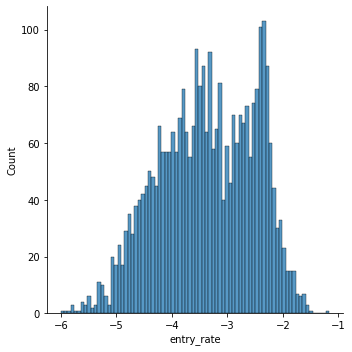

```python
df = df_hh_EnR_ttwaName.copy() # input your data
attribute = "entry_rate" # input your X

import seaborn as sns
import numpy as np
df[attribute] = np.log(df[attribute])
sns.displot(df, x=attribute,bins=80)
```

```
count    3089.000000
mean       10.677960
std         2.702829
min         0.000000
25%        10.502893
50%        11.213327
75%        11.915154
max        15.959450
Name: average_assets, dtype: float64
```

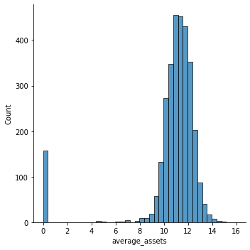

```python
df = df_hh_EnR_ttwaName.copy() # input your data
attribute = "average_assets" # input your X

import seaborn as sns
import numpy as np
df[attribute] = np.log1p(df[attribute])
sns.displot(df, x=attribute,bins=40)
df[attribute].describe()
```

Can we drop the `close to 0` value?

```python
#df_hh_EnR_ttwaName
import math
assets_level = (math.e)**5-1
print(assets_level)
df_hh_EnR_ttwaName[df_hh_EnR_ttwaName.average_assets < assets_level].shape[0] / df_hh_EnR_ttwaName.shape[0]
```

```
147.41315910257657
```

```
0.0534153447717708
```

The 0~4 value only accounts for 0.05 in the dataset, so we can drop our `0` value

```python
df_hh_EnR_ttwaName_asset_not_drop = df_hh_EnR_ttwaName
# drop the asset which can cause outlier
df_hh_EnR_ttwaName = df_hh_EnR_ttwaName[df_hh_EnR_ttwaName["average_assets"]>=assets_level]
```

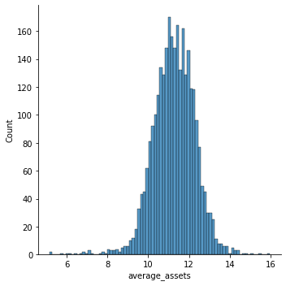

```python
# then test the distribution again
df = df_hh_EnR_ttwaName.copy()
attribute = "average_assets"

import seaborn as sns
import numpy as np
df[attribute] = np.log1p(df[attribute])
sns.displot(df, x=attribute,bins=80)
```

```python
# export the df_hh_EnR_ttwaName_i_t_asset_not_drop
df_hh_EnR_ttwaName_asset_not_drop.to_csv(PATH + "/Dataset/df_hh_EnR_ttwaName_asset_not_drop.csv")
```

## Hypothesis

$\ Dynamics\ Variable_{i,t}\ =\ a_1 + b_1 \ firms_{i,t} + b_2 \ HHI_{i,t} + b_3 \ location_i + b_4 \ year_t + e_{i,t} $ (1)

$\ log_e\ {(Firm\ Performance_{i,t}+1)}\ =\ c_1 + d_1 \ firms_{i,t} + d_2 \ HHI_{i,t} + d_3 \ dynamics_{i,t} + d_4 \ location_i + d_5 \ year_t + e_{i,t}$ (2)

- $t$ means year -- `birth_year`
- $i$ means location -- `ttwa` (travel to work area)
- $Dynamics\ Variable_{i,t}$ in (1) means `Entry_Rate` in $t$ and $i$
- $dynamics_{i,t}$ in (2) means `Entry_Rate` in a specific $t$ and $i$
- $firms_{i,t}$ means `Count_of_tech_firms` in a specific $t$ and $i$
- $HHI_{i,t}$ means `Herfindahl-Hirschman Index` in a specific $t$ and $i$

## OLS with std error

In (1), Y is `entry_rate`, X is `ttwa`, `birth_year`, `total`, `hh`

In (2), Y is `average_latest_accounts_assets`, X is `ttwa`, `birth_year`, `total`, `hh`, `entry_rate`

```python
# environment preparation
import numpy as np
import matplotlib.pyplot as plt
import pandas as pd
from sklearn.linear_model import LinearRegression
import statsmodels.api as sm
import warnings
warnings.filterwarnings('ignore')

pd.set_option('display.max_rows', 300) # specifies number of rows to show
pd.options.display.float_format = '{:40,.4f}'.format # specifies default number format to 4 decimal places
plt.style.use('ggplot') # specifies that graphs should use ggplot styling
%matplotlib inline
```

introduce correlation analysis

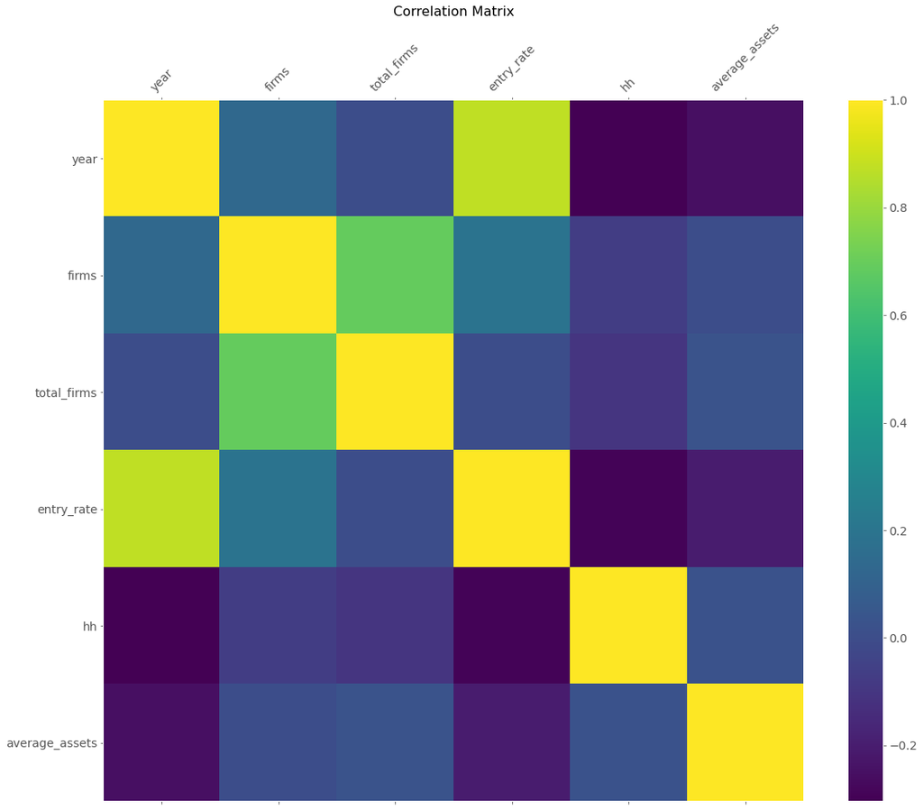

```python
df = df_hh_EnR_ttwaName.copy()

df.year = df.year.astype("int")
df = df.drop({"ttwa","ttwa_code"},axis=1)

# add dummies operation requirement
# Set the reference object is ttwa_E30000234（London）
# drop Birmingham for dummies variables comparasion
# df = df.drop(['ttwa_London'], axis=1)

# correlation analysis
plt.rcParams["axes.grid"] = False
f = plt.figure(figsize=(19, 15))
plt.matshow(df.corr(), fignum=f.number)
plt.xticks(range(df.shape[1]), df.columns, fontsize=14, rotation=45)
plt.yticks(range(df.shape[1]), df.columns, fontsize=14)
cb = plt.colorbar()
cb.ax.tick_params(labelsize=14)
plt.title('Correlation Matrix', fontsize=16)

# df = pd.get_dummies(df)
```

introduce the dummy variables

### Dummies

```python
df = df_hh_EnR_ttwaName.copy()

# intro dummy variables
# df.year = df.year.astype("int")
df = df.drop({"ttwa_code"},axis=1)
df = pd.get_dummies(df)

# add dummies operation requirement
# Set the reference object is ttwa_E30000234（London）
# drop Birmingham for dummies variables comparasion
# df = df.drop(['ttwa_London'], axis=1)

# gd means get dummies
df_hh_EnR_gd = df.copy()
```

### VIF

```python
# VIF method
from statsmodels.stats.outliers_influence import variance_inflation_factor
from statsmodels.tools.tools import add_constant

def drop_column_using_vif_(df, list_var_not_to_remove, thresh=5):
    '''
    Calculates VIF each feature in a pandas dataframe, and repeatedly drop the columns with the highest VIF
    A constant must be added to variance_inflation_factor or the results will be incorrect

    :param df: the pandas dataframe containing only the predictor features, not the response variable
    :param list_var_not_to_remove: the list of variables that should not be removed even though it has a high VIF. For example, dummy (or indicator) variables represent a categorical variable with three or more categories.
    :param thresh: the max VIF value before the feature is removed from the dataframe
    :return: dataframe with multicollinear features removed
    '''
    while True:
        # adding a constatnt item to the data
        df_with_const = add_constant(df)

        vif_df = pd.Series([variance_inflation_factor(df_with_const.values, i)
               for i in range(df_with_const.shape[1])], name= "VIF",
              index=df_with_const.columns).to_frame()

        # drop the const
        vif_df = vif_df.drop('const').drop(list_var_not_to_remove)

        print('Max VIF:', vif_df.VIF.max())

        # if the largest VIF is above the thresh, remove a variable with the largest VIF
        if vif_df.VIF.max() > thresh:
            # If there are multiple variables with the maximum VIF, choose the first one
            index_to_drop = vif_df.index[vif_df.VIF == vif_df.VIF.max()].tolist()[0]
            print('Dropping: {}'.format(index_to_drop))
            df = df.drop(columns = index_to_drop)
        else:
            # No VIF is above threshold. Exit the loop
            break

    return df
```

### All Tech Firms in England (OLS)

In (1):

$\ {Dynamics\ Variable_{i,t}}^{0.5}\ =\ a_1 + b_1 \times firms_{i,t} + b_2 \times HHI_{i,t} + b_3 \times location_i + b_4 \times year_t$

```python
predictors_X = df_hh_EnR_gd.drop({'entry_rate','average_assets'}, axis=1) # drop the Y_1 and Y_2
response_Y = np.sqrt(df_hh_EnR_gd['entry_rate'])
list_var_not_to_remove = ["year","firms","hh"] # this is a list of dummy variables that represent a categorical variable with three or more categories. They should not be removed even if it has a high VIF.

df_predictors_select_VIF = drop_column_using_vif_(predictors_X, list_var_not_to_remove, thresh=5)
print("The columns remaining after VIF selection are:")
print(df_predictors_select_VIF.columns)

regressor_OLS = sm.OLS(endog=response_Y, exog=sm.add_constant(df_predictors_select_VIF)).fit()
regressor_OLS.summary()
```

[output not shown]

In (2):

$\ log_e\ {(Firm\ Performance_{i,t}+1)}\ =\ c_1 + d_1 \times firms_{i,t} + d_2 \times HHI_{i,t} + d_3 \times dynamics_{i,t} + d_4 \times location_i + d_5 \times year_t$ (2)

```python
predictors_X = df_hh_EnR_gd.drop({'average_assets'}, axis=1) # drop the Y_1 and Y_2
response_Y = np.log1p(df_hh_EnR_gd['average_assets'])
list_var_not_to_remove = ["entry_rate","year","firms","hh"] # this is a list of dummy variables that represent a categorical variable with three or more categories. They should not be removed even if it has a high VIF.

df_predictors_select_VIF = drop_column_using_vif_(predictors_X, list_var_not_to_remove, thresh=5)
print("The columns remaining after VIF selection are:")
print(df_predictors_select_VIF.columns)

regressor_OLS = sm.OLS(endog=response_Y, exog=sm.add_constant(df_predictors_select_VIF)).fit()
regressor_OLS.summary()
```

[output not shown]

### Top 10 Tech Cluster (OLS)

small data preparation

```python
df = pd.read_csv(PATH + "/Dataset/fame_OC_tech_firm.csv",low_memory=False)
df = df.drop({"Unnamed: 0","Unnamed: 0.1","Unnamed: 0.1.1","is_tech"},axis = 1)
df = df.dropna(subset = {"birth_year","ttwa"})

# Generate the top 10 tech clusters table based on the ttwa
top_10_ttwa = df.ttwa.value_counts().head(10)
top_10_ttwa = pd.DataFrame(top_10_ttwa).reset_index()
top_10_ttwa.columns = ["ttwa_code","counts"]
```

```python
df_ttwa = pd.read_csv(PATH + "/Dataset/ttwa.csv")
df_ttwa = pd.merge(top_10_ttwa, df_ttwa[["code","name"]], left_on="ttwa_code",right_on="code")
df_ttwa_10 = df_ttwa[["ttwa_code", "name","counts"]]

# df_10_tc means "top 10 tech ttwa clusters"
df_10_tc = df_hh_EnR_ttwaName.copy()
# filter data to top 10 ttwa data raws
df_10_tc = df_10_tc[df_10_tc.ttwa_code.isin(df_ttwa_10.ttwa_code.to_list())].reset_index(drop=True)

df_10_tc = df_10_tc.drop({"ttwa_code"},axis=1)
# get dummies
df_10_tc = pd.get_dummies(df_10_tc)
df_10_tc = df_10_tc.drop({"ttwa_London"},axis=1)

# delete the resid outlier rows
df_10_tc = df_10_tc.drop(index=[182,92,141])
```

In (1):

$\ log_e\ {Dynamics\ Variable_{i,t}}\ =\ a_1 + b_1 \times firms_{i,t} + b_2 \times HHI_{i,t} + b_3 \times location_i + b_4 \times year_t$

```python
df = df_10_tc.copy()

predictors_X = df.drop({'entry_rate','average_assets'}, axis=1) # drop the Y_1 and Y_2
#response_Y = df['entry_rate']
response_Y = np.log(df['entry_rate']) # sqrt is created for residual analysis
list_var_not_to_remove = ["year","firms","hh"] # this is a list of dummy variables that represent a categorical variable with three or more categories. They should not be removed even if it has a high VIF.

df_predictors_select_VIF = drop_column_using_vif_(predictors_X, list_var_not_to_remove, thresh=5)
print("The columns remaining after VIF selection are:")
print(df_predictors_select_VIF.columns)

regressor_OLS = sm.OLS(endog=response_Y, exog=sm.add_constant(df_predictors_select_VIF)).fit()
regressor_OLS.summary()
```

```
Max VIF: inf
Dropping: total_firms
Max VIF: 3.598233664337501
The columns remaining after VIF selection are:
Index(['year', 'firms', 'hh', 'ttwa_Birmingham', 'ttwa_Bournemouth',
       'ttwa_Brighton', 'ttwa_Bristol', 'ttwa_Cambridge',
       'ttwa_Guildford and Aldershot', 'ttwa_Luton', 'ttwa_Manchester',
       'ttwa_Slough and Heathrow'],
      dtype='object')
```

OLS Regression Results

| Dep. Variable: | entry_rate | R-squared: | 0.959 |
| --- | --- | --- | --- |
| Model: | OLS | Adj. R-squared: | 0.957 |
| Method: | Least Squares | F-statistic: | 373.3 |
| Date: | Tue, 03 Aug 2021 | Prob (F-statistic): | 4.84e-125 |
| Time: | 22:09:46 | Log-Likelihood: | 42.872 |
| No. Observations: | 203 | AIC: | -59.74 |
| Df Residuals: | 190 | BIC: | -16.67 |
| Df Model: | 12 |  |  |
| Covariance Type: | nonrobust |  |  |

|  | coef | std err | t | P>\|t\| | [0.025 | 0.975] |
| --- | --- | --- | --- | --- | --- | --- |
| const | -290.6295 | 5.694 | -51.038 | 0.000 | -301.862 | -279.397 |
| year | 0.1427 | 0.003 | 50.089 | 0.000 | 0.137 | 0.148 |
| firms | 3.236e-05 | 8.76e-06 | 3.696 | 0.000 | 1.51e-05 | 4.96e-05 |
| hh | 4.1339 | 0.367 | 11.267 | 0.000 | 3.410 | 4.858 |
| ttwa_Birmingham | 0.2020 | 0.077 | 2.634 | 0.009 | 0.051 | 0.353 |
| ttwa_Bournemouth | -0.8259 | 0.090 | -9.130 | 0.000 | -1.004 | -0.647 |
| ttwa_Brighton | -0.1465 | 0.079 | -1.866 | 0.064 | -0.301 | 0.008 |
| ttwa_Bristol | 0.3233 | 0.077 | 4.180 | 0.000 | 0.171 | 0.476 |
| ttwa_Cambridge | 0.3363 | 0.077 | 4.343 | 0.000 | 0.184 | 0.489 |
| ttwa_Guildford and Aldershot | 0.3654 | 0.078 | 4.703 | 0.000 | 0.212 | 0.519 |
| ttwa_Luton | -0.1255 | 0.081 | -1.553 | 0.122 | -0.285 | 0.034 |
| ttwa_Manchester | 0.2522 | 0.074 | 3.392 | 0.001 | 0.106 | 0.399 |
| ttwa_Slough and Heathrow | 0.1100 | 0.076 | 1.450 | 0.149 | -0.040 | 0.260 |

| Omnibus: | 0.644 | Durbin-Watson: | 1.454 |
| --- | --- | --- | --- |
| Prob(Omnibus): | 0.725 | Jarque-Bera (JB): | 0.744 |
| Skew: | 0.022 | Prob(JB): | 0.689 |
| Kurtosis: | 2.707 | Cond. No. | 1.10e+06 |

Notes:  
[1] Standard Errors assume that the covariance matrix of the errors is correctly specified.  
[2] The condition number is large, 1.1e+06. This might indicate that there are  
strong multicollinearity or other numerical problems.

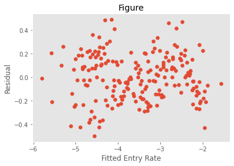

```python
plt.scatter(regressor_OLS.fittedvalues, regressor_OLS.resid)
# adding title and labels
plt.xlabel('Fitted Entry Rate')
plt.ylabel('Residual')
plt.title('Figure')
#plt.ylim(-1,1)
plt.show()
```

In (2):

$\ log_e\ {(Firm\ Performance_{i,t}+1)}\ =\ c_1 + d_1 \times firms_{i,t} + d_2 \times HHI_{i,t} + d_3 \times dynamics_{i,t} + d_4 \times location_i + d_5 \times year_t$ (2)

```python
df = df_10_tc.copy()

predictors_X = df.drop({'average_assets'}, axis=1) # drop the Y_1 and Y_2
response_Y = np.log1p(df['average_assets'])
list_var_not_to_remove = ["entry_rate","year","firms","hh"] # this is a list of dummy variables that represent a categorical variable with three or more categories. They should not be removed even if it has a high VIF.

df_predictors_select_VIF = drop_column_using_vif_(predictors_X, list_var_not_to_remove, thresh=5)
print("The columns remaining after VIF selection are:")
print(df_predictors_select_VIF.columns)

regressor_OLS = sm.OLS(endog=response_Y, exog=sm.add_constant(df_predictors_select_VIF)).fit()
regressor_OLS.summary()
```

```
Max VIF: inf
Dropping: total_firms
Max VIF: 4.045694598536752
The columns remaining after VIF selection are:
Index(['year', 'firms', 'entry_rate', 'hh', 'ttwa_Birmingham',
       'ttwa_Bournemouth', 'ttwa_Brighton', 'ttwa_Bristol', 'ttwa_Cambridge',
       'ttwa_Guildford and Aldershot', 'ttwa_Luton', 'ttwa_Manchester',
       'ttwa_Slough and Heathrow'],
      dtype='object')
```

OLS Regression Results

| Dep. Variable: | average_assets | R-squared: | 0.824 |
| --- | --- | --- | --- |
| Model: | OLS | Adj. R-squared: | 0.811 |
| Method: | Least Squares | F-statistic: | 66.86 |
| Date: | Tue, 03 Aug 2021 | Prob (F-statistic): | 7.71e-63 |
| Time: | 22:46:32 | Log-Likelihood: | -41.356 |
| No. Observations: | 200 | AIC: | 110.7 |
| Df Residuals: | 186 | BIC: | 156.9 |
| Df Model: | 13 |  |  |
| Covariance Type: | nonrobust |  |  |

|  | coef | std err | t | P>\|t\| | [0.025 | 0.975] |
| --- | --- | --- | --- | --- | --- | --- |
| const | 150.1955 | 18.208 | 8.249 | 0.000 | 114.275 | 186.117 |
| year | -0.0688 | 0.009 | -7.569 | 0.000 | -0.087 | -0.051 |
| firms | 3.411e-05 | 1.93e-05 | 1.764 | 0.079 | -4.03e-06 | 7.22e-05 |
| entry_rate | -7.4339 | 1.609 | -4.619 | 0.000 | -10.609 | -4.259 |
| hh | 1.3541 | 0.626 | 2.163 | 0.032 | 0.119 | 2.589 |
| ttwa_Birmingham | -0.2711 | 0.127 | -2.136 | 0.034 | -0.522 | -0.021 |
| ttwa_Bournemouth | -0.6849 | 0.146 | -4.682 | 0.000 | -0.974 | -0.396 |
| ttwa_Brighton | -0.5555 | 0.129 | -4.315 | 0.000 | -0.810 | -0.302 |
| ttwa_Bristol | -0.2290 | 0.129 | -1.777 | 0.077 | -0.483 | 0.025 |
| ttwa_Cambridge | -0.2020 | 0.130 | -1.559 | 0.121 | -0.458 | 0.054 |
| ttwa_Guildford and Aldershot | -0.0727 | 0.129 | -0.564 | 0.573 | -0.327 | 0.182 |
| ttwa_Luton | -0.2907 | 0.131 | -2.218 | 0.028 | -0.549 | -0.032 |
| ttwa_Manchester | -0.1381 | 0.123 | -1.119 | 0.264 | -0.381 | 0.105 |
| ttwa_Slough and Heathrow | -0.1937 | 0.123 | -1.573 | 0.117 | -0.437 | 0.049 |

| Omnibus: | 5.347 | Durbin-Watson: | 1.922 |
| --- | --- | --- | --- |
| Prob(Omnibus): | 0.069 | Jarque-Bera (JB): | 7.800 |
| Skew: | 0.023 | Prob(JB): | 0.0202 |
| Kurtosis: | 3.966 | Cond. No. | 1.99e+06 |

Notes:  
[1] Standard Errors assume that the covariance matrix of the errors is correctly specified.  
[2] The condition number is large, 1.99e+06. This might indicate that there are  
strong multicollinearity or other numerical problems.

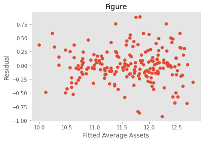

```python
plt.scatter(regressor_OLS.fittedvalues, regressor_OLS.resid)
# adding title and labels
plt.xlabel('Fitted Average Assets')
plt.ylabel('Residual')
plt.title('Figure')
# plt.ylim(-0.5,0.5)
plt.show()
```